# 2018_05_11

John D.

May 11, 2018

## load data

```r
library(ISLR)
library(ggplot2)
library(dplyr)
library(e1071)
library(ROCR)
library(reshape2)
```

# 9.6 Lab: Support Vector Machines

## 9.6.1 Support Vector Classifier

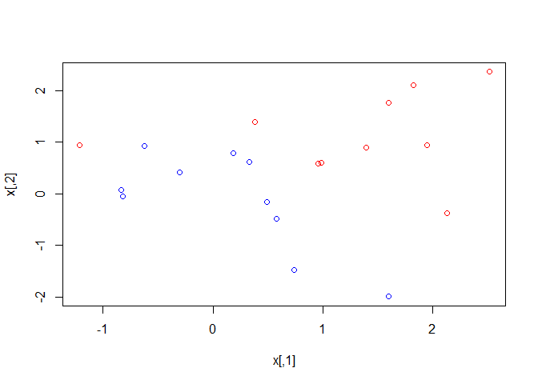

```r
set.seed(1)
x <- matrix(rnorm(20*2), ncol=2)
y <- c(rep(-1,10), rep(1,10))
x[y==1,] <- x[y==1,] + 1
plot(x, col=(3-y))
```

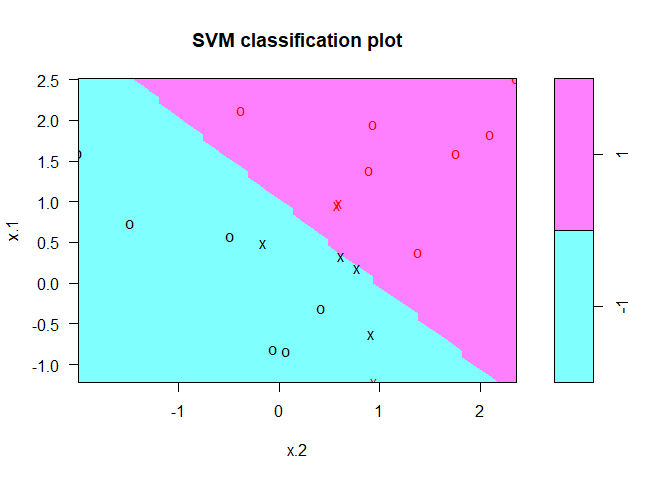

```r
dat <- data.frame(x=x, y=as.factor(y))
svmfit <- svm(y ~., data=dat, kernel = "linear", cost = 10, scale = FALSE)

plot(svmfit, dat)
```

```r
svmfit$index
```

```
## [1]  1  2  5  7 14 16 17
```

```r
summary(svmfit)
```

```
##
## Call:
## svm(formula = y ~ ., data = dat, kernel = "linear", cost = 10,
##     scale = FALSE)
##
##
## Parameters:
##    SVM-Type:  C-classification
##  SVM-Kernel:  linear
##        cost:  10
##       gamma:  0.5
##
## Number of Support Vectors:  7
##
##  ( 4 3 )
##
##
## Number of Classes:  2
##
## Levels:
##  -1 1
```

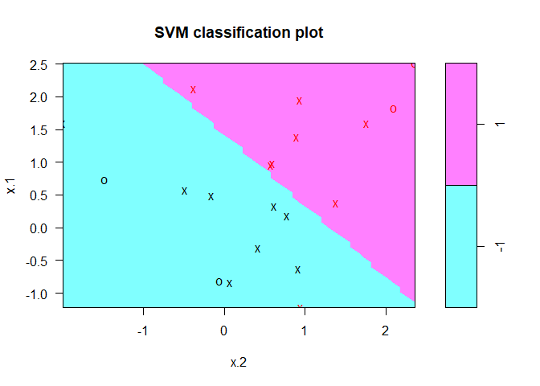

```r
svmfit <- svm(y ~ ., data=dat, kernel = "linear", cost = 0.1, scale=FALSE)
plot(svmfit, dat)
```

```r
svmfit$index
```

```
##  [1]  1  2  3  4  5  7  9 10 12 13 14 15 16 17 18 20
```

```r
set.seed(1)
tune.out <- tune(svm, y ~ ., data=dat, kernel = "linear", ranges=list(cost=c(0.001, 0.01, 0.1, 1, 5, 10, 100)))

summary(tune.out)
```

```
##
## Parameter tuning of 'svm':
##
## - sampling method: 10-fold cross validation
##
## - best parameters:
##  cost
##   0.1
##
## - best performance: 0.1
##
## - Detailed performance results:
##    cost error dispersion
## 1 1e-03  0.70  0.4216370
## 2 1e-02  0.70  0.4216370
## 3 1e-01  0.10  0.2108185
## 4 1e+00  0.15  0.2415229
## 5 5e+00  0.15  0.2415229
## 6 1e+01  0.15  0.2415229
## 7 1e+02  0.15  0.2415229
```

```r
bestmod <- tune.out$best.model
summary(bestmod)
```

```
##
## Call:
## best.tune(method = svm, train.x = y ~ ., data = dat, ranges = list(cost = c(0.001,
##     0.01, 0.1, 1, 5, 10, 100)), kernel = "linear")
##
##
## Parameters:
##    SVM-Type:  C-classification
##  SVM-Kernel:  linear
##        cost:  0.1
##       gamma:  0.5
##
## Number of Support Vectors:  16
##
##  ( 8 8 )
##
##
## Number of Classes:  2
##
## Levels:
##  -1 1
```

```r
xtest <- matrix(rnorm(20*2), ncol=2)
ytest <- sample (c(-1,1), 20, rep=TRUE)
xtest[ytest==1,] <-  xtest[ytest==1,] + 1
testdat <- data.frame(x = xtest, y = as.factor(ytest))

ypred <- predict(bestmod, testdat)
table(predict = ypred, truth = testdat$y)
```

```
##        truth
## predict -1  1
##      -1 11  1
##      1   0  8
```

```r
svmfit <- svm(y ~ ., data=dat, kernel = "linear", cost = .01, scale=FALSE)
ypred <- predict(svmfit, testdat)
table(predict = ypred, truth = testdat$y)
```

```
##        truth
## predict -1  1
##      -1 11  2
##      1   0  7
```

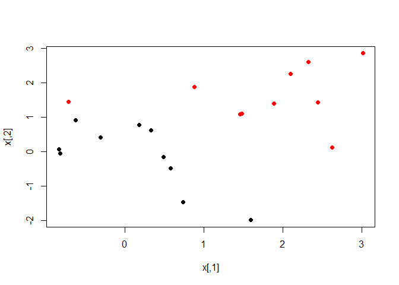

```r
x[y==1,] <- x[y==1,] + 0.5
plot(x, col = (y+3)/2, pch = 19)
```

```r
dat <- data.frame(x = x, y = as.factor(y))
svmfit <- svm(y ~ ., data=dat, kernel = "linear", cost = 1e5)
summary(svmfit)
```

```
##
## Call:
## svm(formula = y ~ ., data = dat, kernel = "linear", cost = 1e+05)
##
##
## Parameters:
##    SVM-Type:  C-classification
##  SVM-Kernel:  linear
##        cost:  1e+05
##       gamma:  0.5
##
## Number of Support Vectors:  3
##
##  ( 1 2 )
##
##
## Number of Classes:  2
##
## Levels:
##  -1 1
```

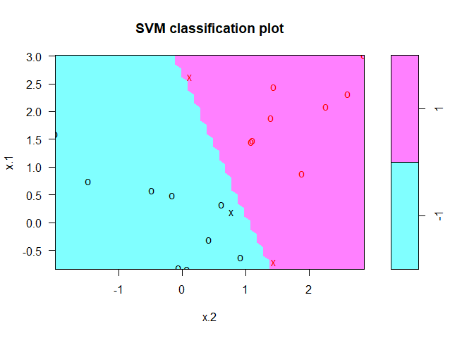

```r
plot(svmfit, dat)
```

```r
svmfit <- svm(y ~ ., data=dat, kernel = "linear", cost = 1)
summary(svmfit)
```

```
##
## Call:
## svm(formula = y ~ ., data = dat, kernel = "linear", cost = 1)
##
##
## Parameters:
##    SVM-Type:  C-classification
##  SVM-Kernel:  linear
##        cost:  1
##       gamma:  0.5
##
## Number of Support Vectors:  7
##
##  ( 4 3 )
##
##
## Number of Classes:  2
##
## Levels:
##  -1 1
```

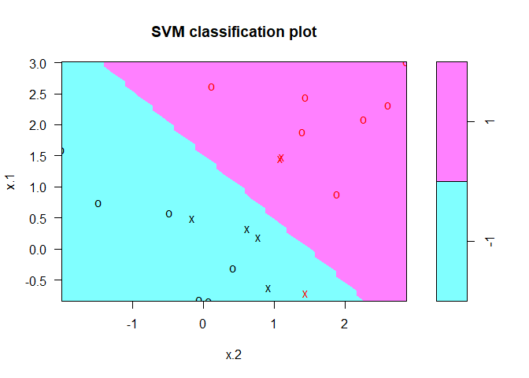

```r
plot(svmfit, dat)
```

## 9.6.2 Support Vector Machine

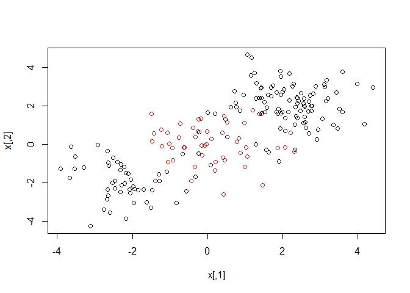

```r
set.seed(1)
x=matrix(rnorm (200*2) , ncol=2)
x[1:100,]=x[1:100,]+2
x[101:150,] = x[101:150,]-2
y=c(rep(1,150) ,rep(2,50))
dat=data.frame(x=x,y=as.factor(y))

plot(x, col=y)
```

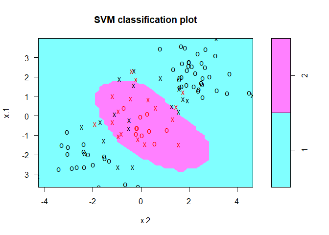

```r
train=sample(200,100)
svmfit=svm(y∼., data=dat[train ,], kernel ="radial", gamma=1,cost=1)
plot(svmfit , dat[train ,])
```

```r
summary(svmfit)
```

```
##
## Call:
## svm(formula = y ~ ., data = dat[train, ], kernel = "radial",
##     gamma = 1, cost = 1)
##
##
## Parameters:
##    SVM-Type:  C-classification
##  SVM-Kernel:  radial
##        cost:  1
##       gamma:  1
##
## Number of Support Vectors:  37
##
##  ( 17 20 )
##
##
## Number of Classes:  2
##
## Levels:
##  1 2
```

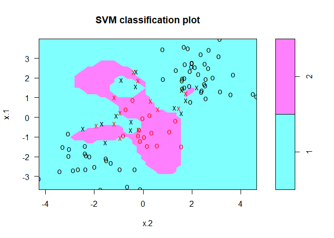

```r
svmfit=svm(y∼., data=dat[train ,], kernel ="radial",gamma=1,cost=1e5)
plot(svmfit ,dat[train ,])
```

```r
set.seed(1)
tune.out=tune(svm , y∼., data=dat[train ,], kernel="radial",ranges=list(cost=c(0.1,1,10,100,1000),gamma=c(0.5,1,2,3,4) ))
summary(tune.out)
```

```
##
## Parameter tuning of 'svm':
##
## - sampling method: 10-fold cross validation
##
## - best parameters:
##  cost gamma
##     1     2
##
## - best performance: 0.12
##
## - Detailed performance results:
##     cost gamma error dispersion
## 1  1e-01   0.5  0.27 0.11595018
## 2  1e+00   0.5  0.13 0.08232726
## 3  1e+01   0.5  0.15 0.07071068
## 4  1e+02   0.5  0.17 0.08232726
## 5  1e+03   0.5  0.21 0.09944289
## 6  1e-01   1.0  0.25 0.13540064
## 7  1e+00   1.0  0.13 0.08232726
## 8  1e+01   1.0  0.16 0.06992059
## 9  1e+02   1.0  0.20 0.09428090
## 10 1e+03   1.0  0.20 0.08164966
## 11 1e-01   2.0  0.25 0.12692955
## 12 1e+00   2.0  0.12 0.09189366
## 13 1e+01   2.0  0.17 0.09486833
## 14 1e+02   2.0  0.19 0.09944289
## 15 1e+03   2.0  0.20 0.09428090
## 16 1e-01   3.0  0.27 0.11595018
## 17 1e+00   3.0  0.13 0.09486833
## 18 1e+01   3.0  0.18 0.10327956
## 19 1e+02   3.0  0.21 0.08755950
## 20 1e+03   3.0  0.22 0.10327956
## 21 1e-01   4.0  0.27 0.11595018
## 22 1e+00   4.0  0.15 0.10801234
## 23 1e+01   4.0  0.18 0.11352924
## 24 1e+02   4.0  0.21 0.08755950
## 25 1e+03   4.0  0.24 0.10749677
```

```r
table(true=dat[-train ,"y"], pred=predict(tune.out$best.model ,newdata =dat[-train ,]))
```

```
##     pred
## true  1  2
##    1 74  3
##    2  7 16
```

## 9.6.3 ROC Curves

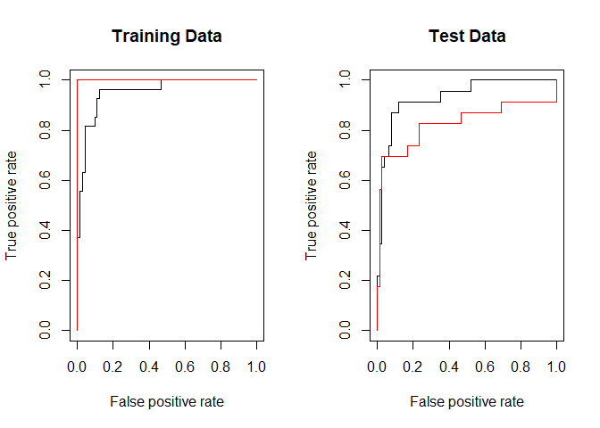

```r
rocplot =function (pred, truth, ...){
  predob = prediction(pred, truth)
  perf = performance(predob, "tpr", "fpr")
  plot(perf,...)}

svmfit.opt=svm(y∼., data=dat[train ,], kernel ="radial", gamma=2, cost=1, decision.values =T)
fitted =attributes(predict(svmfit.opt ,dat[train ,], decision.values=TRUE))$decision.values

par(mfrow=c(1,2))
rocplot(fitted ,dat[train ,"y"], main="Training Data")

svmfit.flex=svm(y∼., data=dat[train ,], kernel ="radial",gamma=50, cost=1, decision.values =T)
fitted=attributes(predict (svmfit.flex ,dat[train ,], decision.values=T))$decision.values
rocplot(fitted ,dat[train ,"y"],add=T,col="red ")

fitted=attributes(predict (svmfit.opt ,dat[-train ,], decision.values=T))$decision.values
rocplot (fitted ,dat[-train ,"y"], main="Test Data")
fitted=attributes (predict (svmfit.flex ,dat[- train ,], decision.values=T))$decision.values
rocplot(fitted ,dat[-train ,"y"],add=T,col="red")
```

## 9.6.4 SVM with Multiple Classes

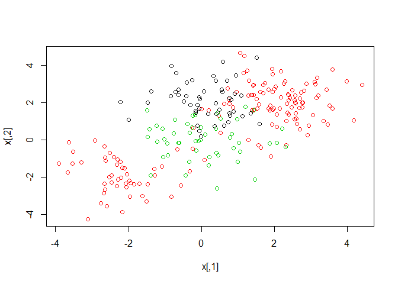

```r
set.seed(1)
x=rbind(x, matrix(rnorm (50*2) , ncol=2))
y=c(y, rep(0,50))
x[y==0,2] = x[y==0 ,2]+2
dat=data.frame(x=x, y=as.factor(y))
par(mfrow=c(1,1))
plot(x,col=(y+1))
```

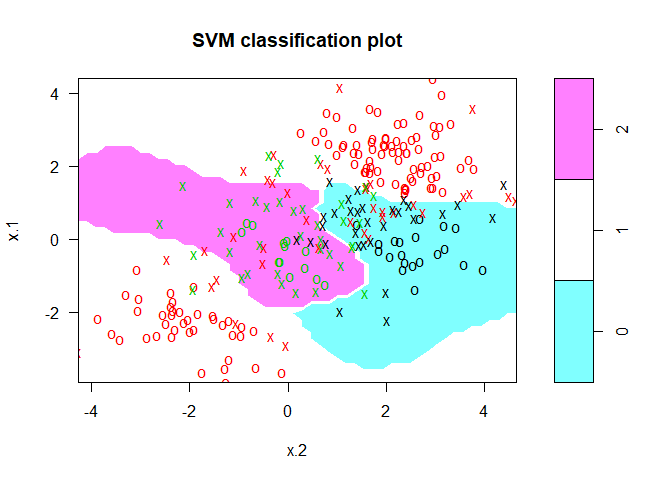

```r
svmfit=svm(y∼., data=dat , kernel ="radial", cost=10, gamma =1)
plot(svmfit, dat)
```

## 9.6.5 Application to Gene Expression Data

```r
names(Khan)
```

```
## [1] "xtrain" "xtest"  "ytrain" "ytest"
```

```r
dim(Khan$xtrain)
```

```
## [1]   63 2308
```

```r
dim(Khan$xtest)
```

```
## [1]   20 2308
```

```r
length(Khan$ytrain)
```

```
## [1] 63
```

```r
length(Khan$ytest)
```

```
## [1] 20
```

```r
table(Khan$ytrain)
```

```
##
##  1  2  3  4
##  8 23 12 20
```

```r
table(Khan$ytest)
```

```
##
## 1 2 3 4
## 3 6 6 5
```

```r
dat=data.frame(x=Khan$xtrain , y=as.factor(Khan$ytrain ))
out=svm(y∼., data=dat, kernel ="linear",cost=10)
summary(out)
```

```
##
## Call:
## svm(formula = y ~ ., data = dat, kernel = "linear", cost = 10)
##
##
## Parameters:
##    SVM-Type:  C-classification
##  SVM-Kernel:  linear
##        cost:  10
##       gamma:  0.0004332756
##
## Number of Support Vectors:  58
##
##  ( 20 20 11 7 )
##
##
## Number of Classes:  4
##
## Levels:
##  1 2 3 4
```

```r
table(out$fitted , dat$y)
```

```
##
##      1  2  3  4
##   1  8  0  0  0
##   2  0 23  0  0
##   3  0  0 12  0
##   4  0  0  0 20
```

```r
dat.te=data.frame(x=Khan$xtest , y=as.factor(Khan$ytest ))
pred.te=predict(out, newdata=dat.te)
table(pred.te, dat.te$y)
```

```
##
## pred.te 1 2 3 4
##       1 3 0 0 0
##       2 0 6 2 0
##       3 0 0 4 0
##       4 0 0 0 5
```

## 4. Generate a simulated two-class data set with 100 observations and two features in which there is a visible but non-linear separation between the two classes. Show that in this setting, a support vector machine with a polynomial kernel (with degree greater than 1) or a radial kernel will outperform a support vector classifier on the training data. Which technique performs best on the test data? Make plots and report training and test error rates in order to back up your assertions.

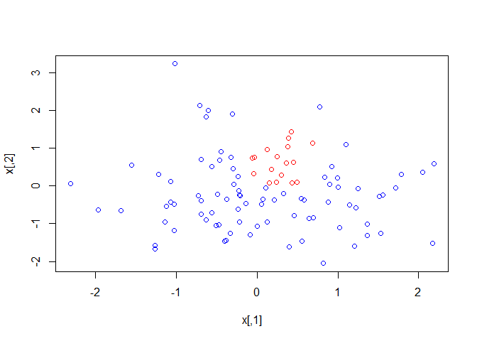

```r
# Make data
set.seed(123)
x <- matrix(rnorm (100*2) , ncol=2)
y <- ifelse(x[,1] > -.1 & x[,1] < .75 & x[,2] > 0 & x[,2] < 1.5, -1, 1)
dat=data.frame(x=x, y=as.factor(y))
par(mfrow=c(1,1))
plot(x,col=(y+3))
```

```r
# Create training set
train <- sample(100, 75)

# Linear
linear.tune<- tune(svm, y ~ ., data=dat[train,], kernel = "linear", ranges=list(cost=c(0.01, 0.1, 1, 5, 10)))
summary(linear.tune)
```

```
##
## Parameter tuning of 'svm':
##
## - sampling method: 10-fold cross validation
##
## - best parameters:
##  cost
##  0.01
##
## - best performance: 0.1857143
##
## - Detailed performance results:
##    cost     error dispersion
## 1  0.01 0.1857143  0.1645701
## 2  0.10 0.1857143  0.1645701
## 3  1.00 0.1857143  0.1645701
## 4  5.00 0.1857143  0.1645701
## 5 10.00 0.1857143  0.1645701
```

```r
linear.bestmod <- linear.tune$best.model
summary(linear.bestmod)
```

```
##
## Call:
## best.tune(method = svm, train.x = y ~ ., data = dat[train, ],
##     ranges = list(cost = c(0.01, 0.1, 1, 5, 10)), kernel = "linear")
##
##
## Parameters:
##    SVM-Type:  C-classification
##  SVM-Kernel:  linear
##        cost:  0.01
##       gamma:  0.5
##
## Number of Support Vectors:  30
##
##  ( 16 14 )
##
##
## Number of Classes:  2
##
## Levels:
##  -1 1
```

```r
table(predict = predict(linear.bestmod, dat[train,]), truth = dat[train,3])
```

```
##        truth
## predict -1  1
##      -1  0  0
##      1  14 61
```

```r
100 - sum(predict(linear.bestmod, dat[train,]) == dat[train,3])/length(dat[train,3])*100
```

```
## [1] 18.66667
```

```r
# 18.67% training error

table(predict = predict(linear.bestmod, dat[-train,]), truth = dat[-train,3])
```

```
##        truth
## predict -1  1
##      -1  0  0
##      1   3 22
```

```r
100 - sum(predict(linear.bestmod, dat[-train,]) == dat[-train,3])/length(dat[-train,3])*100
```

```
## [1] 12
```

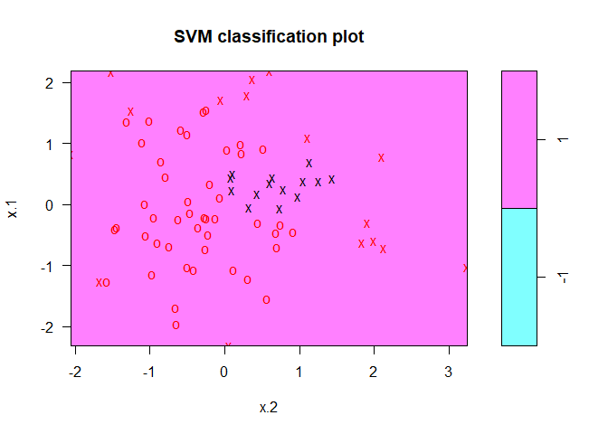

```r
# 12% test error

plot(linear.bestmod, dat[train,])
```

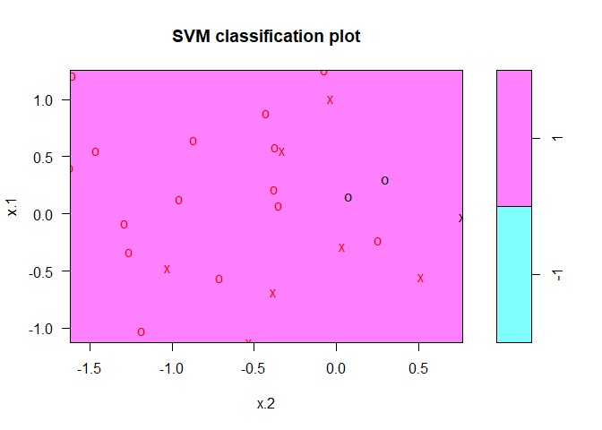

```r
plot(linear.bestmod, dat[-train,])
```

```r
# Radial
radial.tune<- tune(svm, y ~ ., data=dat[train,], kernel="radial",ranges=list(cost=c(0.1,1,10,100,1000),gamma=c(0.5,1,2,3,4)))
summary(radial.tune)
```

```
##
## Parameter tuning of 'svm':
##
## - sampling method: 10-fold cross validation
##
## - best parameters:
##  cost gamma
##   100   0.5
##
## - best performance: 0
##
## - Detailed performance results:
##     cost gamma      error dispersion
## 1  1e-01   0.5 0.18035714 0.11858541
## 2  1e+00   0.5 0.06607143 0.06994997
## 3  1e+01   0.5 0.05178571 0.06705351
## 4  1e+02   0.5 0.00000000 0.00000000
## 5  1e+03   0.5 0.00000000 0.00000000
## 6  1e-01   1.0 0.18035714 0.11858541
## 7  1e+00   1.0 0.05178571 0.06705351
## 8  1e+01   1.0 0.02678571 0.05662589
## 9  1e+02   1.0 0.00000000 0.00000000
## 10 1e+03   1.0 0.00000000 0.00000000
## 11 1e-01   2.0 0.18035714 0.11858541
## 12 1e+00   2.0 0.02500000 0.05270463
## 13 1e+01   2.0 0.00000000 0.00000000
## 14 1e+02   2.0 0.00000000 0.00000000
## 15 1e+03   2.0 0.00000000 0.00000000
## 16 1e-01   3.0 0.18035714 0.11858541
## 17 1e+00   3.0 0.03750000 0.06038074
## 18 1e+01   3.0 0.00000000 0.00000000
## 19 1e+02   3.0 0.00000000 0.00000000
## 20 1e+03   3.0 0.00000000 0.00000000
## 21 1e-01   4.0 0.18035714 0.11858541
## 22 1e+00   4.0 0.05000000 0.08740074
## 23 1e+01   4.0 0.00000000 0.00000000
## 24 1e+02   4.0 0.00000000 0.00000000
## 25 1e+03   4.0 0.00000000 0.00000000
```

```r
radial.bestmod <- radial.tune$best.model
summary(radial.bestmod)
```

```
##
## Call:
## best.tune(method = svm, train.x = y ~ ., data = dat[train, ],
##     ranges = list(cost = c(0.1, 1, 10, 100, 1000), gamma = c(0.5,
##         1, 2, 3, 4)), kernel = "radial")
##
##
## Parameters:
##    SVM-Type:  C-classification
##  SVM-Kernel:  radial
##        cost:  100
##       gamma:  0.5
##
## Number of Support Vectors:  7
##
##  ( 3 4 )
##
##
## Number of Classes:  2
##
## Levels:
##  -1 1
```

```r
table(predict = predict(radial.bestmod, dat[train,]), truth = dat[train,3])
```

```
##        truth
## predict -1  1
##      -1 14  0
##      1   0 61
```

```r
100 - sum(predict(radial.bestmod, dat[train,]) == dat[train,3])/length(dat[train,3])*100
```

```
## [1] 0
```

```r
# 0% training error

table(predict = predict(radial.bestmod, dat[-train,]), truth = dat[-train,3])
```

```
##        truth
## predict -1  1
##      -1  3  0
##      1   0 22
```

```r
100 - sum(predict(radial.bestmod, dat[-train,]) == dat[-train,3])/length(dat[-train,3])*100
```

```
## [1] 0
```

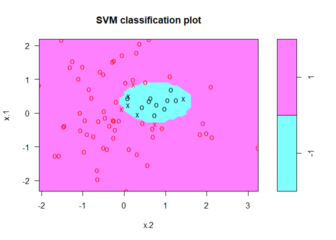

```r
# 0% test error

plot(radial.bestmod, dat[train,])
```

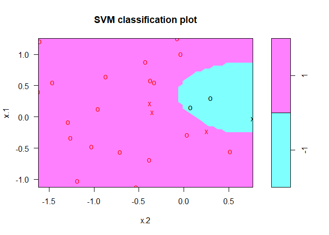

```r
plot(radial.bestmod, dat[-train,])
```

## 5. We have seen that we can fit an SVM with a non-linear kernel in order to perform classification using a non-linear decision boundary. We will now see that we can also obtain a non-linear decision boundary by performing logistic regression using non-linear transformations of the features.

1. Generate a data set with n = 500 and p = 2, such that the observations belong to two classes with a quadratic decision boundary between them. For instance, you can do this as follows:

```r
x1 <- runif(500)-0.5
x2 <- runif(500)-0.5
y <- 1*(x1^2-x2^2 > 0)
```

2. Plot the observations, colored according to their class labels. Your plot should display X1 on the x-axis, and X2 on the yaxis.

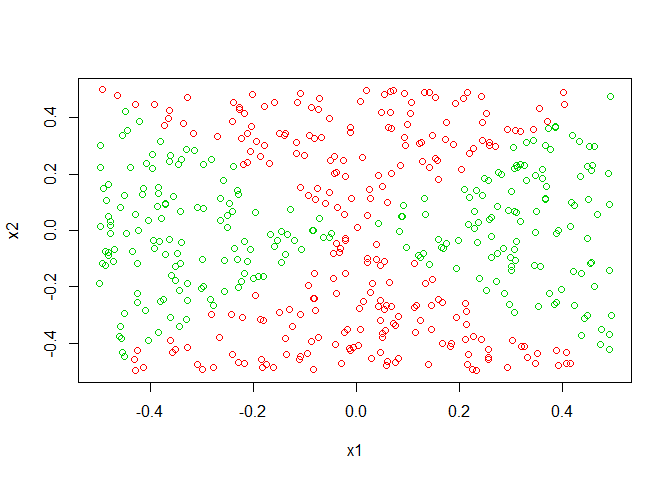

```r
plot(x1,x2, col = c(y + 2))
```

3. Fit a logistic regression model to the data, using X1 and X2 as predictors.

```r
train <- sample(500,400)
dat <- data.frame(x1,x2, y = factor(y))
glm.fits=glm(y ∼ ., data=dat[train,] ,family=binomial)
summary(glm.fits)
```

```
##
## Call:
## glm(formula = y ~ ., family = binomial, data = dat[train, ])
##
## Deviance Residuals:
##    Min      1Q  Median      3Q     Max
## -1.263  -1.160  -1.081   1.188   1.287
##
## Coefficients:
##             Estimate Std. Error z value Pr(>|z|)
## (Intercept) -0.03987    0.10022  -0.398    0.691
## x1          -0.26243    0.35733  -0.734    0.463
## x2           0.21798    0.34902   0.625    0.532
##
## (Dispersion parameter for binomial family taken to be 1)
##
##     Null deviance: 554.36  on 399  degrees of freedom
## Residual deviance: 553.42  on 397  degrees of freedom
## AIC: 559.42
##
## Number of Fisher Scoring iterations: 3
```

4. Apply this model to the training data in order to obtain a predicted class label for each training observation. Plot the observations, colored according to the predicted class labels. The decision boundary should be linear.

```r
glm.probs <- predict(glm.fits, type="response")
contrasts(dat$y)
```

```
##   1
## 0 0
## 1 1
```

```r
glm.pred <- rep(0 ,400)
glm.pred[glm.probs >.5] <- 1
table(glm.pred, dat[train,]$y)
```

```
##
## glm.pred   0   1
##        0 139 123
##        1  65  73
```

```r
mean(glm.pred == dat[train,]$y)
```

```
## [1] 0.53
```

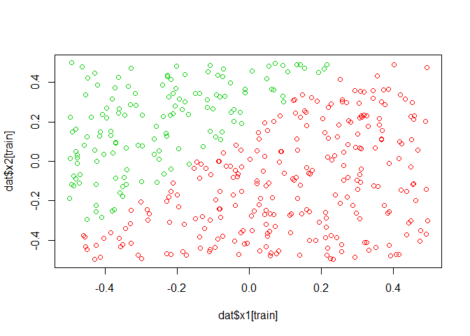

```r
plot(dat$x1[train], dat$x2[train], col = c(glm.pred + 2))
```

5. Now fit a logistic regression model to the data using non-linear functions of X1 and X2 as predictors (e.g. X2 1 , X1×X2, log(X2), and so forth).

```r
glm.fits=glm(y ∼ x1 + x2 + I(x1^2) + I(x2^2) + x1*x2, data=dat[train,] ,family=binomial)
summary(glm.fits)
```

```
##
## Call:
## glm(formula = y ~ x1 + x2 + I(x1^2) + I(x2^2) + x1 * x2, family = binomial,
##     data = dat[train, ])
##
## Deviance Residuals:
##        Min          1Q      Median          3Q         Max
## -1.305e-03  -2.000e-08  -2.000e-08   2.000e-08   9.856e-04
##
## Coefficients:
##               Estimate Std. Error z value Pr(>|z|)
## (Intercept)    -12.706   1107.082  -0.011    0.991
## x1             192.974  56431.754   0.003    0.997
## x2             -17.824 107483.251   0.000    1.000
## I(x1^2)      17089.348 591419.534   0.029    0.977
## I(x2^2)     -16520.621 629297.749  -0.026    0.979
## x1:x2           -5.035 305950.994   0.000    1.000
##
## (Dispersion parameter for binomial family taken to be 1)
##
##     Null deviance: 5.5436e+02  on 399  degrees of freedom
## Residual deviance: 3.3076e-06  on 394  degrees of freedom
## AIC: 12
##
## Number of Fisher Scoring iterations: 25
```

6. Apply this model to the training data in order to obtain a predicted class label for each training observation. Plot the observations, colored according to the predicted class labels. The decision boundary should be obviously non-linear. If it is not, then repeat (a)-(e) until you come up with an example in which the predicted class labels are obviously non-linear.

```r
glm.probs <- predict(glm.fits, type="response")
glm.pred <- rep(0 ,400)
glm.pred[glm.probs >.5] <- 1
table(glm.pred, dat[train,]$y)
```

```
##
## glm.pred   0   1
##        0 204   0
##        1   0 196
```

```r
mean(glm.pred == dat[train,]$y)
```

```
## [1] 1
```

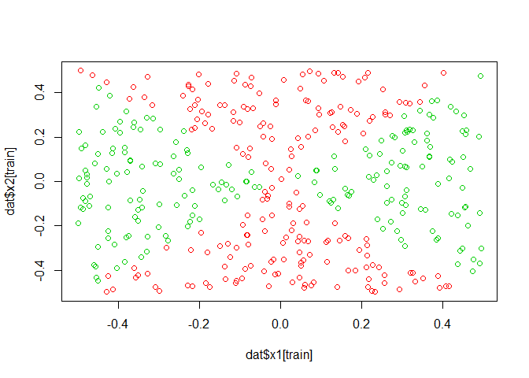

```r
plot(dat$x1[train], dat$x2[train], col = c(glm.pred + 2))
```

7. Fit a support vector classifier to the data with X1 and X2 as predictors. Obtain a class prediction for each training observation. Plot the observations, colored according to the predicted class labels.

```r
svc.tune  <- tune(svm, y ∼ . , data=dat[train,], kernel="linear", ranges=list(cost=c(0.001, 0.01, 0.1, 1, 5, 10, 100)))
svc.fit <- svc.tune$best.model

table(predict = predict(svc.fit, dat[train,]), truth = dat[train,3])
```

```
##        truth
## predict   0   1
##       0 140  98
##       1  64  98
```

```r
100 - sum(predict(svc.fit, dat[train,]) == dat[train,3])/length(dat[train,3])*100
```

```
## [1] 40.5
```

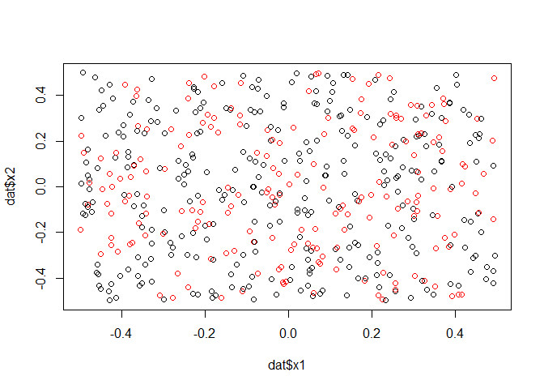

```r
plot(dat$x1, dat$x2, col = c(predict(svc.fit, dat[train,])))
```

8. Fit a SVM using a non-linear kernel to the data. Obtain a class prediction for each training observation. Plot the observations, colored according to the predicted class labels.

```r
# Radial
svm.tune  <- tune(svm, y ∼ . , data=dat[train,], kernel="radial",ranges=list(cost=c(0.1,1,10,100,1000),gamma=c(0.5,1,2,3,4)))
svm.fit <- svm.tune$best.model

table(predict = predict(svm.fit, dat[train,]), truth = dat[train,3])
```

```
##        truth
## predict   0   1
##       0 203   1
##       1   1 195
```

```r
100 - sum(predict(svm.fit, dat[train,]) == dat[train,3])/length(dat[train,3])*100
```

```
## [1] 0.5
```

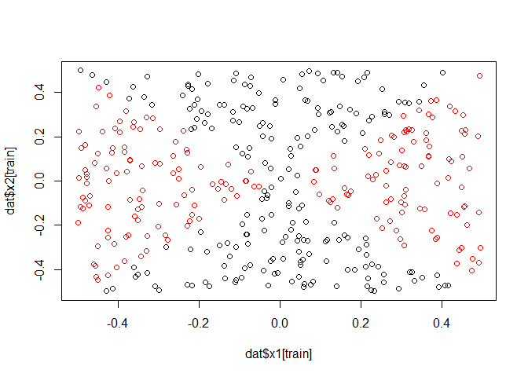

```r
plot(dat$x1[train], dat$x2[train], col = c(predict(svm.fit, dat[train,])))
```

```r
# Polynomial
svm.tune  <- tune(svm, y ∼ . , data=dat[train,], kernel="polynomial",ranges=list(cost=c(0.1,1,10,100,1000),degree=c(1,2,3)))
svm.fit <- svm.tune$best.model

table(predict = predict(svm.fit, dat[train,]), truth = dat[train,3])
```

```
##        truth
## predict   0   1
##       0 202   1
##       1   2 195
```

```r
100 - sum(predict(svm.fit, dat[train,]) == dat[train,3])/length(dat[train,3])*100
```

```
## [1] 0.75
```

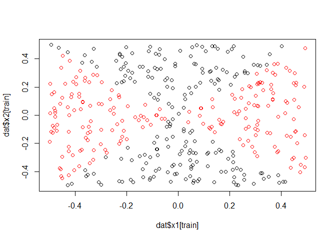

```r
plot(dat$x1[train], dat$x2[train], col = c(predict(svm.fit, dat[train,])))
```

1. Comment on your results.

Similar

# #7. In this problem, you will use support vector approaches in order to predict whether a given car gets high or low gas mileage based on the Auto data set.

1. Create a binary variable that takes on a 1 for cars with gas mileage above the median, and a 0 for cars with gas mileage below the median.

```r
summary(Auto)
```

```
##       mpg          cylinders      displacement     horsepower
##  Min.   : 9.00   Min.   :3.000   Min.   : 68.0   Min.   : 46.0
##  1st Qu.:17.00   1st Qu.:4.000   1st Qu.:105.0   1st Qu.: 75.0
##  Median :22.75   Median :4.000   Median :151.0   Median : 93.5
##  Mean   :23.45   Mean   :5.472   Mean   :194.4   Mean   :104.5
##  3rd Qu.:29.00   3rd Qu.:8.000   3rd Qu.:275.8   3rd Qu.:126.0
##  Max.   :46.60   Max.   :8.000   Max.   :455.0   Max.   :230.0
##
##      weight      acceleration        year           origin
##  Min.   :1613   Min.   : 8.00   Min.   :70.00   Min.   :1.000
##  1st Qu.:2225   1st Qu.:13.78   1st Qu.:73.00   1st Qu.:1.000
##  Median :2804   Median :15.50   Median :76.00   Median :1.000
##  Mean   :2978   Mean   :15.54   Mean   :75.98   Mean   :1.577
##  3rd Qu.:3615   3rd Qu.:17.02   3rd Qu.:79.00   3rd Qu.:2.000
##  Max.   :5140   Max.   :24.80   Max.   :82.00   Max.   :3.000
##
##                  name
##  amc matador       :  5
##  ford pinto        :  5
##  toyota corolla    :  5
##  amc gremlin       :  4
##  amc hornet        :  4
##  chevrolet chevette:  4
##  (Other)           :365
```

```r
Auto$efficiency <- as.factor(ifelse(Auto$mpg > median(Auto$mpg), 1, 0))
```

2. Fit a support vector classifier to the data with various values of cost, in order to predict whether a car gets high or low gas mileage. Report the cross-validation errors associated with different values of this parameter. Comment on your results.

```r
set.seed(1)
tune.out <- tune(svm, efficiency ~ ., data=Auto, kernel = "linear", ranges=list(cost=c(0.001, 0.01, 0.1, 1, 5, 10, 100)))

summary(tune.out)
```

```
##
## Parameter tuning of 'svm':
##
## - sampling method: 10-fold cross validation
##
## - best parameters:
##  cost
##     1
##
## - best performance: 0.01275641
##
## - Detailed performance results:
##    cost      error dispersion
## 1 1e-03 0.09442308 0.03837365
## 2 1e-02 0.07403846 0.05471525
## 3 1e-01 0.03826923 0.05148114
## 4 1e+00 0.01275641 0.01344780
## 5 5e+00 0.01782051 0.01229997
## 6 1e+01 0.02038462 0.01074682
## 7 1e+02 0.03820513 0.01773427
```

```r
summary(tune.out)$best.performance
```

```
## [1] 0.01275641
```

```r
linear.bestmod <- tune.out$best.model
summary(linear.bestmod)
```

```
##
## Call:
## best.tune(method = svm, train.x = efficiency ~ ., data = Auto,
##     ranges = list(cost = c(0.001, 0.01, 0.1, 1, 5, 10, 100)),
##     kernel = "linear")
##
##
## Parameters:
##    SVM-Type:  C-classification
##  SVM-Kernel:  linear
##        cost:  1
##       gamma:  0.003205128
##
## Number of Support Vectors:  56
##
##  ( 26 30 )
##
##
## Number of Classes:  2
##
## Levels:
##  0 1
```

Best cost was somewhere around 1 and 5.

3. Now repeat (b), this time using SVMs with radial and polynomial basis kernels, with different values of gamma and degree and cost. Comment on your results.

```r
#Radial
tune.out <- tune(svm, efficiency ~ ., data=Auto, kernel = "radial", ranges=list(cost=c(0.1,1,10,100,1000),gamma=c(0.5,1,2,3,4)))

summary(tune.out)
```

```
##
## Parameter tuning of 'svm':
##
## - sampling method: 10-fold cross validation
##
## - best parameters:
##  cost gamma
##     1   0.5
##
## - best performance: 0.04596154
##
## - Detailed performance results:
##     cost gamma      error dispersion
## 1  1e-01   0.5 0.07916667 0.04084188
## 2  1e+00   0.5 0.04596154 0.02026662
## 3  1e+01   0.5 0.04839744 0.01859159
## 4  1e+02   0.5 0.04839744 0.01859159
## 5  1e+03   0.5 0.04839744 0.01859159
## 6  1e-01   1.0 0.55871795 0.05068311
## 7  1e+00   1.0 0.06634615 0.03842264
## 8  1e+01   1.0 0.06628205 0.03999233
## 9  1e+02   1.0 0.06628205 0.03999233
## 10 1e+03   1.0 0.06628205 0.03999233
## 11 1e-01   2.0 0.55871795 0.05068311
## 12 1e+00   2.0 0.11493590 0.09230772
## 13 1e+01   2.0 0.11493590 0.09230772
## 14 1e+02   2.0 0.11493590 0.09230772
## 15 1e+03   2.0 0.11493590 0.09230772
## 16 1e-01   3.0 0.55871795 0.05068311
## 17 1e+00   3.0 0.37435897 0.18793801
## 18 1e+01   3.0 0.35403846 0.18582768
## 19 1e+02   3.0 0.35403846 0.18582768
## 20 1e+03   3.0 0.35403846 0.18582768
## 21 1e-01   4.0 0.55871795 0.05068311
## 22 1e+00   4.0 0.48205128 0.08140100
## 23 1e+01   4.0 0.47948718 0.07702036
## 24 1e+02   4.0 0.47948718 0.07702036
## 25 1e+03   4.0 0.47948718 0.07702036
```

```r
summary(tune.out)$best.performance
```

```
## [1] 0.04596154
```

```r
radial.bestmod <- tune.out$best.model
summary(radial.bestmod)
```

```
##
## Call:
## best.tune(method = svm, train.x = efficiency ~ ., data = Auto,
##     ranges = list(cost = c(0.1, 1, 10, 100, 1000), gamma = c(0.5,
##         1, 2, 3, 4)), kernel = "radial")
##
##
## Parameters:
##    SVM-Type:  C-classification
##  SVM-Kernel:  radial
##        cost:  1
##       gamma:  0.5
##
## Number of Support Vectors:  276
##
##  ( 136 140 )
##
##
## Number of Classes:  2
##
## Levels:
##  0 1
```

```r
tune.out <- tune(svm, efficiency ~ ., data=Auto, kernel = "polynomial", ranges=list(cost=c(0.1,1,10,100,1000),degree=c(1,2,3)))

summary(tune.out)
```

```
##
## Parameter tuning of 'svm':
##
## - sampling method: 10-fold cross validation
##
## - best parameters:
##  cost degree
##  1000      1
##
## - best performance: 0.01269231
##
## - Detailed performance results:
##     cost degree      error dispersion
## 1  1e-01      1 0.18102564 0.11678135
## 2  1e+00      1 0.08166667 0.04624398
## 3  1e+01      1 0.07147436 0.04943915
## 4  1e+02      1 0.01275641 0.01344780
## 5  1e+03      1 0.01269231 0.01783081
## 6  1e-01      2 0.58673077 0.03560377
## 7  1e+00      2 0.58673077 0.03560377
## 8  1e+01      2 0.57647436 0.02810467
## 9  1e+02      2 0.30346154 0.07928888
## 10 1e+03      2 0.25217949 0.08777199
## 11 1e-01      3 0.58673077 0.03560377
## 12 1e+00      3 0.58673077 0.03560377
## 13 1e+01      3 0.58673077 0.03560377
## 14 1e+02      3 0.34948718 0.11255059
## 15 1e+03      3 0.24993590 0.05389739
```

```r
summary(tune.out)$best.performance
```

```
## [1] 0.01269231
```

```r
poly.bestmod <- tune.out$best.model
summary(poly.bestmod)
```

```
##
## Call:
## best.tune(method = svm, train.x = efficiency ~ ., data = Auto,
##     ranges = list(cost = c(0.1, 1, 10, 100, 1000), degree = c(1,
##         2, 3)), kernel = "polynomial")
##
##
## Parameters:
##    SVM-Type:  C-classification
##  SVM-Kernel:  polynomial
##        cost:  1000
##      degree:  1
##       gamma:  0.003205128
##      coef.0:  0
##
## Number of Support Vectors:  49
##
##  ( 25 24 )
##
##
## Number of Classes:  2
##
## Levels:
##  0 1
```

4. Make some plots to back up your assertions in (b) and (c).

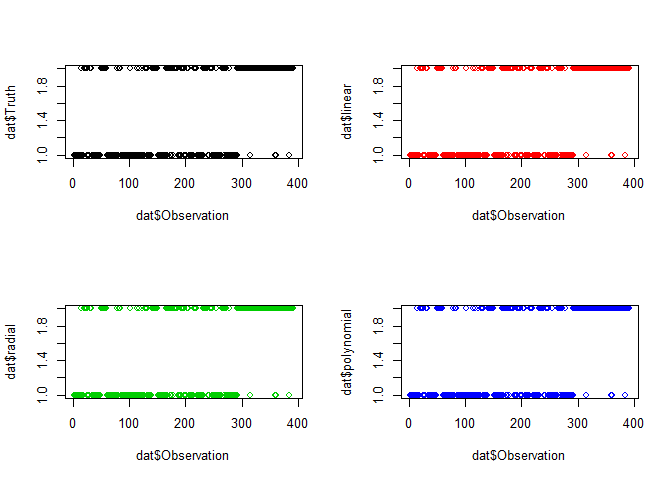

```r
dat <- data.frame(Observation = 1:nrow(Auto), Truth = Auto$efficiency, linear = predict(linear.bestmod, Auto),
                  radial = predict(radial.bestmod, Auto), polynomial = predict(poly.bestmod, Auto))
par(mfrow=c(2,2))
plot(dat$Observation,dat$Truth, col = 1)
plot(dat$Observation,dat$linear, col = 2)
plot(dat$Observation,dat$radial, col = 3)
plot(dat$Observation,dat$polynomial, col = 4)
```